# EAN_2

## GUIA 2

#### Jeremy Eduardo Andres Jerez Barona

Actividad 1. Limpieza iterativa.

*Producto: Escribir en un archivo tipo html de Jupyter bloques de código y Markdown donde se tomen las variables de una base dada y se les describa lo siguiente:*

**Limpieza de un carácter especial.**

Se les apliquen funciones correspondientes al tipo de ellas para:

**La cantidad de valores que hay.** **Valores distintos.** **Valores nulos.**

Actividades especificas guia 2:

**Reducción de los nits de longitud mayor a 9**

#### Primero Cargaremos el dataset

```python
import pandas as pd

df_empresas = pd.read_csv(r"C:\Users\Jedan\Downloads\OTROS\10.000_Empresas_mas_Grandes_del_Pa_s_20240822.csv")
#df_empresas = pd.read_csv(r"C:\Users\Jedan\Informacion\Learning\EAN\Programacion\10.000_Empresas_mas_Grandes_del_Pa_s_20240822.csv")
```

```python
df_empresas
```

|  | NIT | RAZÓN SOCIAL | SUPERVISOR | REGIÓN | DEPARTAMENTO DOMICILIO | CIUDAD DOMICILIO | CIIU | MACROSECTOR | INGRESOS OPERACIONALES | GANANCIA (PÉRDIDA) | TOTAL ACTIVOS | TOTAL PASIVOS | TOTAL PATRIMONIO | Año de Corte |
| --- | --- | --- | --- | --- | --- | --- | --- | --- | --- | --- | --- | --- | --- | --- |
| 0 | 899999068 | ECOPETROL S.A | SUPERFINANCIERA | Bogotá - Cundinamarca | BOGOTA D.C. | BOGOTA D.C.-BOGOTA D.C. | 610 | MINERO | $144.82 | $33.41 | $216.85 | $125.81 | $91.03 | 2022 |
| 1 | 900112515 | REFINERIA DE CARTAGENA S.A.S | SUPERSOCIEDADES | Costa Atlántica | BOLIVAR | CARTAGENA-BOLIVAR | 1921 | MANUFACTURA | $27.86 | $2.19 | $42.84 | $16.48 | $26.36 | 2022 |
| 2 | 830095213 | ORGANIZACIÓN TERPEL S.A. | SUPERFINANCIERA | Bogotá - Cundinamarca | BOGOTA D.C. | BOGOTA D.C.-BOGOTA D.C. | 4661 | COMERCIO | $23.60 | $0.33 | $7.48 | $4.47 | $3.01 | 2022 |
| 3 | 860069804 | CARBONES DEL CERREJON LIMITED | SUPERSOCIEDADES | Bogotá - Cundinamarca | BOGOTA D.C. | BOGOTA D.C.-BOGOTA D.C. | 510 | MINERO | $16.39 | $6.05 | $10.45 | $9.00 | $1.45 | 2022 |
| 4 | 800021308 | DRUMMOND LTD | SUPERSOCIEDADES | Bogotá - Cundinamarca | BOGOTA D.C. | BOGOTA D.C.-BOGOTA D.C. | 510 | MINERO | $15.27 | $2.16 | $14.27 | $6.34 | $7.93 | 2022 |
| ... | ... | ... | ... | ... | ... | ... | ... | ... | ... | ... | ... | ... | ... | ... |
| 19995 | 900440256 | EFIVENTAS Y SERVICIOS SAS | SUPERSOCIEDADES | Costa Atlántica | ATLANTICO | BARRANQUILLA-ATLANTICO | 7490 | SERVICIOS | $0.01 | $0.00 | $0.01 | $0.01 | $0.00 | 2021 |
| 19996 | 890115230 | QUIMIFEX SAS | SUPERSOCIEDADES | Costa Atlántica | ATLANTICO | BARRANQUILLA-ATLANTICO | 4664 | COMERCIO | $0.01 | $0.00 | $0.01 | $0.01 | $0.00 | 2021 |
| 19997 | 901021850 | EDGE NETWORK SERVICES COLOMBIA SAS | SUPERSOCIEDADES | Bogotá - Cundinamarca | BOGOTA D.C. | BOGOTA D.C.-BOGOTA D.C. | 6190 | SERVICIOS | $0.01 | $0.00 | $0.04 | $0.00 | $0.04 | 2021 |
| 19998 | 900350192 | DESTINO COMERCIAL SAS | SUPERSOCIEDADES | Antioquia | ANTIOQUIA | SABANETA-ANTIOQUIA | 4771 | COMERCIO | $0.01 | $0.00 | $0.01 | $0.00 | $0.00 | 2021 |
| 19999 | 830123119 | DISTRIBUIDORA DE MAQUINARIA AGRICOLA Y PECUARI... | SUPERSOCIEDADES | Bogotá - Cundinamarca | CUNDINAMARCA | CHIA-CUNDINAMARCA | 4653 | COMERCIO | $0.01 | $0.00 | $0.01 | $0.01 | $0.00 | 2021 |

20000 rows × 14 columns

#### Ahora comenzaremos analizando el tipo de variable de dataframe:

```python
print(f"Tipos de variable del dataset Empresas:\n\n{df_empresas.dtypes}")
```

```
Tipos de variable del dataset Empresas:

NIT                        int64
RAZÓN SOCIAL              object
SUPERVISOR                object
REGIÓN                    object
DEPARTAMENTO DOMICILIO    object
CIUDAD DOMICILIO          object
CIIU                       int64
MACROSECTOR               object
INGRESOS OPERACIONALES    object
GANANCIA (PÉRDIDA)        object
TOTAL ACTIVOS             object
TOTAL PASIVOS             object
TOTAL PATRIMONIO          object
Año de Corte               int64
dtype: object
```

#### Tenemos una estructura muy clara del DF con Int y strings con caracteristicas muy claras, sin embargo los strings tienen guiones y simbolos que pueden llegar a requerir un preprocesamiento de la informacion

### **Analisis de cantidades en el DF Empresas**

```python
filas_i, columnas_i = df_empresas.shape
print(f"Numero de filas: {filas_i}")
print(f"Numero de columnas: {columnas_i}")

#Opcion 1
Valores_unicos_empresas = df_empresas.nunique()
#print(f"\nValores unicos de cada columna:\n{Valores_unicos_empresas}")

#Opcion 2 con proporcion de valores unicos sobre el total
summario_df_empresas = pd.DataFrame({
    'Valores Unicos': Valores_unicos_empresas,
    'Total de registros': [filas_i] * columnas_i
})
summario_df_empresas['% de valores unicos'] = (summario_df_empresas['Valores Unicos'] / summario_df_empresas['Total de registros']) * 100

summario_df_empresas
```

```
Numero de filas: 20000
Numero de columnas: 14
```

|  | Valores Unicos | Total de registros | % de valores unicos |
| --- | --- | --- | --- |
| NIT | 11441 | 20000 | 57.205 |
| RAZÓN SOCIAL | 11436 | 20000 | 57.180 |
| SUPERVISOR | 6 | 20000 | 0.030 |
| REGIÓN | 7 | 20000 | 0.035 |
| DEPARTAMENTO DOMICILIO | 33 | 20000 | 0.165 |
| CIUDAD DOMICILIO | 348 | 20000 | 1.740 |
| CIIU | 389 | 20000 | 1.945 |
| MACROSECTOR | 6 | 20000 | 0.030 |
| INGRESOS OPERACIONALES | 321 | 20000 | 1.605 |
| GANANCIA (PÉRDIDA) | 150 | 20000 | 0.750 |
| TOTAL ACTIVOS | 387 | 20000 | 1.935 |
| TOTAL PASIVOS | 263 | 20000 | 1.315 |
| TOTAL PATRIMONIO | 331 | 20000 | 1.655 |
| Año de Corte | 2 | 20000 | 0.010 |

##### Descriptiva

```python
df_empresas.describe()
```

|  | NIT | CIIU | Año de Corte |
| --- | --- | --- | --- |
| count | 2.000000e+04 | 20000.000000 | 20000.000000 |
| mean | 8.616976e+08 | 4612.116150 | 2021.500000 |
| std | 4.091783e+07 | 2392.183829 | 0.500013 |
| min | 8.000001e+08 | 111.000000 | 2021.000000 |
| 25% | 8.200016e+08 | 2819.000000 | 2021.000000 |
| 50% | 8.902089e+08 | 4659.000000 | 2021.500000 |
| 75% | 9.003244e+08 | 6202.000000 | 2022.000000 |
| max | 9.016500e+08 | 9609.000000 | 2022.000000 |

##### Valores nulos

```python
nulos_empresas = df_empresas.isnull().sum()

# Calculo de porcentaje de nulos en cada columna
nulos_empresas_Porcentaje = (nulos_empresas / len(df_empresas)) * 100
nulos_summary = pd.DataFrame({
    'Valores Nulos': nulos_empresas,
    'Porcentaje Null': nulos_empresas_Porcentaje
})

# Ordenar por nulos
nulos_summary = nulos_summary.sort_values(by='Valores Nulos', ascending=False)

nulos_summary
```

|  | Valores Nulos | Porcentaje Null |
| --- | --- | --- |
| RAZÓN SOCIAL | 2 | 0.01 |
| NIT | 0 | 0.00 |
| SUPERVISOR | 0 | 0.00 |
| REGIÓN | 0 | 0.00 |
| DEPARTAMENTO DOMICILIO | 0 | 0.00 |
| CIUDAD DOMICILIO | 0 | 0.00 |
| CIIU | 0 | 0.00 |
| MACROSECTOR | 0 | 0.00 |
| INGRESOS OPERACIONALES | 0 | 0.00 |
| GANANCIA (PÉRDIDA) | 0 | 0.00 |
| TOTAL ACTIVOS | 0 | 0.00 |
| TOTAL PASIVOS | 0 | 0.00 |
| TOTAL PATRIMONIO | 0 | 0.00 |
| Año de Corte | 0 | 0.00 |

##### Eliminar celdas o columnas con valores nulos

```python
# Opción 1: Eliminar filas con valores nulos y modificar el DataFrame original
df_empresas.dropna(inplace=True)

# Opción 2: Eliminar una columna completamente si se supera un threshold o umbral (porcentaje) de valores nulos
#threshold = 50.0
#columns_to_drop = nulos_summary[nulos_summary['Porcentaje Null'] > threshold].index
#df_empresas.drop(columns=columns_to_drop, inplace=True)

df_empresas
```

|  | NIT | RAZÓN SOCIAL | SUPERVISOR | REGIÓN | DEPARTAMENTO DOMICILIO | CIUDAD DOMICILIO | CIIU | MACROSECTOR | INGRESOS OPERACIONALES | GANANCIA (PÉRDIDA) | TOTAL ACTIVOS | TOTAL PASIVOS | TOTAL PATRIMONIO | Año de Corte |
| --- | --- | --- | --- | --- | --- | --- | --- | --- | --- | --- | --- | --- | --- | --- |
| 0 | 899999068 | ECOPETROL S.A | SUPERFINANCIERA | Bogotá - Cundinamarca | BOGOTA D.C. | BOGOTA D.C.-BOGOTA D.C. | 610 | MINERO | $144.82 | $33.41 | $216.85 | $125.81 | $91.03 | 2022 |
| 1 | 900112515 | REFINERIA DE CARTAGENA S.A.S | SUPERSOCIEDADES | Costa Atlántica | BOLIVAR | CARTAGENA-BOLIVAR | 1921 | MANUFACTURA | $27.86 | $2.19 | $42.84 | $16.48 | $26.36 | 2022 |
| 2 | 830095213 | ORGANIZACIÓN TERPEL S.A. | SUPERFINANCIERA | Bogotá - Cundinamarca | BOGOTA D.C. | BOGOTA D.C.-BOGOTA D.C. | 4661 | COMERCIO | $23.60 | $0.33 | $7.48 | $4.47 | $3.01 | 2022 |
| 3 | 860069804 | CARBONES DEL CERREJON LIMITED | SUPERSOCIEDADES | Bogotá - Cundinamarca | BOGOTA D.C. | BOGOTA D.C.-BOGOTA D.C. | 510 | MINERO | $16.39 | $6.05 | $10.45 | $9.00 | $1.45 | 2022 |
| 4 | 800021308 | DRUMMOND LTD | SUPERSOCIEDADES | Bogotá - Cundinamarca | BOGOTA D.C. | BOGOTA D.C.-BOGOTA D.C. | 510 | MINERO | $15.27 | $2.16 | $14.27 | $6.34 | $7.93 | 2022 |
| ... | ... | ... | ... | ... | ... | ... | ... | ... | ... | ... | ... | ... | ... | ... |
| 19995 | 900440256 | EFIVENTAS Y SERVICIOS SAS | SUPERSOCIEDADES | Costa Atlántica | ATLANTICO | BARRANQUILLA-ATLANTICO | 7490 | SERVICIOS | $0.01 | $0.00 | $0.01 | $0.01 | $0.00 | 2021 |
| 19996 | 890115230 | QUIMIFEX SAS | SUPERSOCIEDADES | Costa Atlántica | ATLANTICO | BARRANQUILLA-ATLANTICO | 4664 | COMERCIO | $0.01 | $0.00 | $0.01 | $0.01 | $0.00 | 2021 |
| 19997 | 901021850 | EDGE NETWORK SERVICES COLOMBIA SAS | SUPERSOCIEDADES | Bogotá - Cundinamarca | BOGOTA D.C. | BOGOTA D.C.-BOGOTA D.C. | 6190 | SERVICIOS | $0.01 | $0.00 | $0.04 | $0.00 | $0.04 | 2021 |
| 19998 | 900350192 | DESTINO COMERCIAL SAS | SUPERSOCIEDADES | Antioquia | ANTIOQUIA | SABANETA-ANTIOQUIA | 4771 | COMERCIO | $0.01 | $0.00 | $0.01 | $0.00 | $0.00 | 2021 |
| 19999 | 830123119 | DISTRIBUIDORA DE MAQUINARIA AGRICOLA Y PECUARI... | SUPERSOCIEDADES | Bogotá - Cundinamarca | CUNDINAMARCA | CHIA-CUNDINAMARCA | 4653 | COMERCIO | $0.01 | $0.00 | $0.01 | $0.01 | $0.00 | 2021 |

19998 rows × 14 columns

#### *Limpieza con if en el DF*

Dado que tenemos varias columnas con simbolos y guiones en el Df, vamos a realizar una iteracion para: remover "-", remover "$"

```python
# Seleccionar columnas para reemplazar
columnas_reemplazo = ['REGIÓN', 'DEPARTAMENTO DOMICILIO','CIUDAD DOMICILIO','INGRESOS OPERACIONALES','GANANCIA (PÉRDIDA)',
                      'TOTAL ACTIVOS','TOTAL PASIVOS','TOTAL PATRIMONIO']

# Iteracion y remplazo de simbolo "-"
for col in columnas_reemplazo:
    df_empresas[col] = df_empresas[col].str.replace("-", " ").str.replace("$", "")

# Reemplazo de puntos por comas opcional
#columnas_valores = ['INGRESOS OPERACIONALES','GANANCIA (PÉRDIDA)','TOTAL ACTIVOS','TOTAL PASIVOS','TOTAL PATRIMONIO']
#for col in columnas_valores:
#    df_empresas[col] = df_empresas[col].str.replace(".", ",")

df_empresas
```

|  | NIT | RAZÓN SOCIAL | SUPERVISOR | REGIÓN | DEPARTAMENTO DOMICILIO | CIUDAD DOMICILIO | CIIU | MACROSECTOR | INGRESOS OPERACIONALES | GANANCIA (PÉRDIDA) | TOTAL ACTIVOS | TOTAL PASIVOS | TOTAL PATRIMONIO | Año de Corte |
| --- | --- | --- | --- | --- | --- | --- | --- | --- | --- | --- | --- | --- | --- | --- |
| 0 | 899999068 | ECOPETROL S.A | SUPERFINANCIERA | Bogotá Cundinamarca | BOGOTA D.C. | BOGOTA D.C. BOGOTA D.C. | 610 | MINERO | 144.82 | 33.41 | 216.85 | 125.81 | 91.03 | 2022 |
| 1 | 900112515 | REFINERIA DE CARTAGENA S.A.S | SUPERSOCIEDADES | Costa Atlántica | BOLIVAR | CARTAGENA BOLIVAR | 1921 | MANUFACTURA | 27.86 | 2.19 | 42.84 | 16.48 | 26.36 | 2022 |
| 2 | 830095213 | ORGANIZACIÓN TERPEL S.A. | SUPERFINANCIERA | Bogotá Cundinamarca | BOGOTA D.C. | BOGOTA D.C. BOGOTA D.C. | 4661 | COMERCIO | 23.60 | 0.33 | 7.48 | 4.47 | 3.01 | 2022 |
| 3 | 860069804 | CARBONES DEL CERREJON LIMITED | SUPERSOCIEDADES | Bogotá Cundinamarca | BOGOTA D.C. | BOGOTA D.C. BOGOTA D.C. | 510 | MINERO | 16.39 | 6.05 | 10.45 | 9.00 | 1.45 | 2022 |
| 4 | 800021308 | DRUMMOND LTD | SUPERSOCIEDADES | Bogotá Cundinamarca | BOGOTA D.C. | BOGOTA D.C. BOGOTA D.C. | 510 | MINERO | 15.27 | 2.16 | 14.27 | 6.34 | 7.93 | 2022 |
| ... | ... | ... | ... | ... | ... | ... | ... | ... | ... | ... | ... | ... | ... | ... |
| 19995 | 900440256 | EFIVENTAS Y SERVICIOS SAS | SUPERSOCIEDADES | Costa Atlántica | ATLANTICO | BARRANQUILLA ATLANTICO | 7490 | SERVICIOS | 0.01 | 0.00 | 0.01 | 0.01 | 0.00 | 2021 |
| 19996 | 890115230 | QUIMIFEX SAS | SUPERSOCIEDADES | Costa Atlántica | ATLANTICO | BARRANQUILLA ATLANTICO | 4664 | COMERCIO | 0.01 | 0.00 | 0.01 | 0.01 | 0.00 | 2021 |
| 19997 | 901021850 | EDGE NETWORK SERVICES COLOMBIA SAS | SUPERSOCIEDADES | Bogotá Cundinamarca | BOGOTA D.C. | BOGOTA D.C. BOGOTA D.C. | 6190 | SERVICIOS | 0.01 | 0.00 | 0.04 | 0.00 | 0.04 | 2021 |
| 19998 | 900350192 | DESTINO COMERCIAL SAS | SUPERSOCIEDADES | Antioquia | ANTIOQUIA | SABANETA ANTIOQUIA | 4771 | COMERCIO | 0.01 | 0.00 | 0.01 | 0.00 | 0.00 | 2021 |
| 19999 | 830123119 | DISTRIBUIDORA DE MAQUINARIA AGRICOLA Y PECUARI... | SUPERSOCIEDADES | Bogotá Cundinamarca | CUNDINAMARCA | CHIA CUNDINAMARCA | 4653 | COMERCIO | 0.01 | 0.00 | 0.01 | 0.01 | 0.00 | 2021 |

19998 rows × 14 columns

## Actividad 2. Transformación de datos.

### Actividades especificas guia 2:

#### Reducción de los nits de longitud mayor a 9.

```python
# TRANSFORMACION DE DATOS

# Convertir la columna 'NIT' a cadenas de texto temporalmente para medir la longitud
df_empresas['NIT_str'] = df_empresas['NIT'].astype(str)

# Filtrar valores con longitud mayor a 9
df_empresas_reducido = df_empresas[df_empresas['NIT_str'].apply(len) <= 9]

# Eliminar columna temporal 'NIT_str'
df_empresas_reducido.drop(columns=['NIT_str'], inplace=True)

df_empresas_reducido
```

|  | NIT | RAZÓN SOCIAL | SUPERVISOR | REGIÓN | DEPARTAMENTO DOMICILIO | CIUDAD DOMICILIO | CIIU | MACROSECTOR | INGRESOS OPERACIONALES | GANANCIA (PÉRDIDA) | TOTAL ACTIVOS | TOTAL PASIVOS | TOTAL PATRIMONIO | Año de Corte |
| --- | --- | --- | --- | --- | --- | --- | --- | --- | --- | --- | --- | --- | --- | --- |
| 0 | 899999068 | ECOPETROL S.A | SUPERFINANCIERA | Bogotá Cundinamarca | BOGOTA D.C. | BOGOTA D.C. BOGOTA D.C. | 610 | MINERO | 144.82 | 33.41 | 216.85 | 125.81 | 91.03 | 2022 |
| 1 | 900112515 | REFINERIA DE CARTAGENA S.A.S | SUPERSOCIEDADES | Costa Atlántica | BOLIVAR | CARTAGENA BOLIVAR | 1921 | MANUFACTURA | 27.86 | 2.19 | 42.84 | 16.48 | 26.36 | 2022 |
| 2 | 830095213 | ORGANIZACIÓN TERPEL S.A. | SUPERFINANCIERA | Bogotá Cundinamarca | BOGOTA D.C. | BOGOTA D.C. BOGOTA D.C. | 4661 | COMERCIO | 23.60 | 0.33 | 7.48 | 4.47 | 3.01 | 2022 |
| 3 | 860069804 | CARBONES DEL CERREJON LIMITED | SUPERSOCIEDADES | Bogotá Cundinamarca | BOGOTA D.C. | BOGOTA D.C. BOGOTA D.C. | 510 | MINERO | 16.39 | 6.05 | 10.45 | 9.00 | 1.45 | 2022 |
| 4 | 800021308 | DRUMMOND LTD | SUPERSOCIEDADES | Bogotá Cundinamarca | BOGOTA D.C. | BOGOTA D.C. BOGOTA D.C. | 510 | MINERO | 15.27 | 2.16 | 14.27 | 6.34 | 7.93 | 2022 |
| ... | ... | ... | ... | ... | ... | ... | ... | ... | ... | ... | ... | ... | ... | ... |
| 19995 | 900440256 | EFIVENTAS Y SERVICIOS SAS | SUPERSOCIEDADES | Costa Atlántica | ATLANTICO | BARRANQUILLA ATLANTICO | 7490 | SERVICIOS | 0.01 | 0.00 | 0.01 | 0.01 | 0.00 | 2021 |
| 19996 | 890115230 | QUIMIFEX SAS | SUPERSOCIEDADES | Costa Atlántica | ATLANTICO | BARRANQUILLA ATLANTICO | 4664 | COMERCIO | 0.01 | 0.00 | 0.01 | 0.01 | 0.00 | 2021 |
| 19997 | 901021850 | EDGE NETWORK SERVICES COLOMBIA SAS | SUPERSOCIEDADES | Bogotá Cundinamarca | BOGOTA D.C. | BOGOTA D.C. BOGOTA D.C. | 6190 | SERVICIOS | 0.01 | 0.00 | 0.04 | 0.00 | 0.04 | 2021 |
| 19998 | 900350192 | DESTINO COMERCIAL SAS | SUPERSOCIEDADES | Antioquia | ANTIOQUIA | SABANETA ANTIOQUIA | 4771 | COMERCIO | 0.01 | 0.00 | 0.01 | 0.00 | 0.00 | 2021 |
| 19999 | 830123119 | DISTRIBUIDORA DE MAQUINARIA AGRICOLA Y PECUARI... | SUPERSOCIEDADES | Bogotá Cundinamarca | CUNDINAMARCA | CHIA CUNDINAMARCA | 4653 | COMERCIO | 0.01 | 0.00 | 0.01 | 0.01 | 0.00 | 2021 |

19998 rows × 14 columns

#### **AL parecer en el dataset no hay nits con len mayor a 9**

```python
print(f"Tipos de variable del dataset actual:\n\n{df_empresas_reducido.dtypes}")
```

```
Tipos de variable del dataset actual:

NIT                        int64
RAZÓN SOCIAL              object
SUPERVISOR                object
REGIÓN                    object
DEPARTAMENTO DOMICILIO    object
CIUDAD DOMICILIO          object
CIIU                       int64
MACROSECTOR               object
INGRESOS OPERACIONALES    object
GANANCIA (PÉRDIDA)        object
TOTAL ACTIVOS             object
TOTAL PASIVOS             object
TOTAL PATRIMONIO          object
Año de Corte               int64
dtype: object
```

### Convertir tipo variable

```python
# Lista de columnas que necesitamos convertir a float
columnas_a_convertir = ['INGRESOS OPERACIONALES', 'GANANCIA (PÉRDIDA)', 'TOTAL ACTIVOS', 'TOTAL PASIVOS', 'TOTAL PATRIMONIO']

# Convertir columnas predefinidas a float
df_empresas[columnas_a_convertir] = df_empresas[columnas_a_convertir].replace(",", "", regex=True)  # Eliminar comas si existen
df_empresas[columnas_a_convertir] = df_empresas[columnas_a_convertir].astype(float)

# Verificar que las columnas han sido convertidas a float
print(f"tipo de variable columnas convertidas :\n\n{df_empresas[columnas_a_convertir].dtypes}")
print(f"\nTipos de variable del dataset actual:\n\n{df_empresas.dtypes}")
```

```
tipo de variable columnas convertidas :

INGRESOS OPERACIONALES    float64
GANANCIA (PÉRDIDA)        float64
TOTAL ACTIVOS             float64
TOTAL PASIVOS             float64
TOTAL PATRIMONIO          float64
dtype: object

Tipos de variable del dataset actual:

NIT                         int64
RAZÓN SOCIAL               object
SUPERVISOR                 object
REGIÓN                     object
DEPARTAMENTO DOMICILIO     object
CIUDAD DOMICILIO           object
CIIU                        int64
MACROSECTOR                object
INGRESOS OPERACIONALES    float64
GANANCIA (PÉRDIDA)        float64
TOTAL ACTIVOS             float64
TOTAL PASIVOS             float64
TOTAL PATRIMONIO          float64
Año de Corte                int64
NIT_str                    object
dtype: object
```

### CONCLUSIONES

A medida que avanzamos en la materia logramos entender muchas mas funciones procedimientos y ayudas que nos sirven para el procesamiento de los datos, en este caso utilizamos funciones de limpieza y transformacion basicas pero efectivas que nos ayudan a preparar nuestra data para la descriptiva y las visualizaciones.

En esta guia logre trabajar algunas funciones y loops que son fundamentales para comprender la informacion que recibimos y como debemos transformar la informacion para analizarla correctamente

### Analis extra, ahora podemos con la data preparada realizar un analisis

```python
# Análisis estadístico descriptivo
# Columnas de interés
columnas_interes = ['INGRESOS OPERACIONALES', 'GANANCIA (PÉRDIDA)', 'TOTAL ACTIVOS', 'TOTAL PASIVOS', 'TOTAL PATRIMONIO']

# Análisis estadístico para columnas específicas
descripcion_columnas = df_empresas[columnas_interes].describe()
descripcion_columnas
```

|  | INGRESOS OPERACIONALES | GANANCIA (PÉRDIDA) | TOTAL ACTIVOS | TOTAL PASIVOS | TOTAL PATRIMONIO |
| --- | --- | --- | --- | --- | --- |
| count | 19998.000000 | 19998.000000 | 19998.000000 | 19998.000000 | 19998.000000 |
| mean | 0.151706 | 0.017475 | 0.198055 | 0.098076 | 0.102823 |
| std | 1.341852 | 0.291312 | 2.286939 | 1.264216 | 1.107424 |
| min | 0.010000 | 0.000000 | 0.000000 | 0.000000 | 0.000000 |
| 25% | 0.020000 | 0.000000 | 0.010000 | 0.010000 | 0.010000 |
| 50% | 0.040000 | 0.000000 | 0.030000 | 0.020000 | 0.010000 |
| 75% | 0.080000 | 0.010000 | 0.080000 | 0.040000 | 0.030000 |
| max | 144.820000 | 33.410000 | 216.850000 | 125.810000 | 91.030000 |

```python
#! pip install seaborn
```

```
                        INGRESOS OPERACIONALES  GANANCIA (PÉRDIDA)  \
INGRESOS OPERACIONALES                1.000000            0.910489
GANANCIA (PÉRDIDA)                    0.910489            1.000000
TOTAL ACTIVOS                         0.906956            0.915482
TOTAL PASIVOS                         0.936816            0.910176
TOTAL PATRIMONIO                      0.806274            0.854407

                        TOTAL ACTIVOS  TOTAL PASIVOS  TOTAL PATRIMONIO
INGRESOS OPERACIONALES       0.906956       0.936816          0.806274
GANANCIA (PÉRDIDA)           0.915482       0.910176          0.854407
TOTAL ACTIVOS                1.000000       0.968677          0.961028
TOTAL PASIVOS                0.968677       1.000000          0.864447
TOTAL PATRIMONIO             0.961028       0.864447          1.000000
```

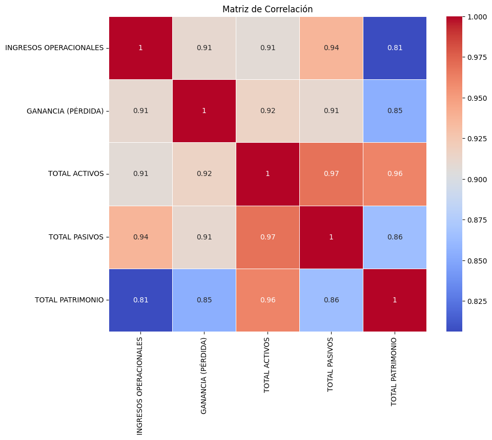

```python
# Matriz de correlación
correlacion = df_empresas[columnas_interes].corr()
print(correlacion)

# Visualización de la matriz de correlación
import seaborn as sns
import matplotlib.pyplot as plt

plt.figure(figsize=(10, 8))
sns.heatmap(correlacion, annot=True, cmap='coolwarm', linewidths=0.5)
plt.title("Matriz de Correlación")
plt.show()
```

Correlación Positiva Alta:

- INGRESOS OPERACIONALES y GANANCIA (PÉRDIDA) (0.91): Existe una fuerte relación positiva entre los ingresos operacionales y las ganancias. Esto significa que, en general, a medida que aumentan los ingresos, también tienden a aumentar las ganancias. Es un resultado esperado en la mayoría de los casos.
- TOTAL ACTIVOS y TOTAL PASIVOS (0.97): Los activos totales y los pasivos totales también están muy correlacionados positivamente. Esto sugiere que las empresas que tienen muchos activos también suelen tener muchos pasivos. Es común en empresas que operan con altos niveles de endeudamiento.
- TOTAL ACTIVOS y TOTAL PATRIMONIO (0.96): Una alta correlación entre activos y patrimonio indica que, a medida que aumentan los activos de una empresa, también suele aumentar su patrimonio. Correlaciones Moderadas a Fuertes:
- TOTAL ACTIVOS y INGRESOS OPERACIONALES (0.91): Existe una fuerte correlación positiva entre los activos totales y los ingresos operacionales, lo que sugiere que las empresas con más activos tienden a generar más ingresos.
- TOTAL PATRIMONIO y GANANCIA (PÉRDIDA) (0.85): También hay una fuerte relación entre el patrimonio total y las ganancias, indicando que las empresas con mayor patrimonio suelen ser más rentables. Correlación Moderada:
- INGRESOS OPERACIONALES y TOTAL PATRIMONIO (0.81): Aunque la correlación no es tan fuerte como en los casos anteriores, sigue siendo positiva y significativa. Esto sugiere que las empresas con más ingresos operacionales tienden a tener un mayor patrimonio, aunque la relación no es tan directa como en los otros casos.

```python
# Análisis agrupado por REGIÓN Solo para ingresos operacionales
analisis_por_region = df_empresas.groupby('REGIÓN')['INGRESOS OPERACIONALES'].describe()
analisis_por_region
```

| REGIÓN | count | mean | std | min | 25% | 50% | 75% | max |
| --- | --- | --- | --- | --- | --- | --- | --- | --- |
| Antioquia | 3821.0 | 0.132256 | 0.569476 | 0.01 | 0.02 | 0.04 | 0.08 | 15.13 |
| Bogotá Cundinamarca | 9288.0 | 0.193636 | 1.890243 | 0.01 | 0.02 | 0.04 | 0.09 | 144.82 |
| Centro Oriente | 1162.0 | 0.077676 | 0.138903 | 0.01 | 0.02 | 0.03 | 0.07 | 2.30 |
| Costa Atlántica | 2161.0 | 0.131601 | 0.778625 | 0.01 | 0.02 | 0.03 | 0.07 | 27.86 |
| Costa Pacífica | 2187.0 | 0.116534 | 0.286445 | 0.01 | 0.02 | 0.04 | 0.08 | 4.92 |
| Eje Cafetero | 707.0 | 0.092107 | 0.217371 | 0.01 | 0.02 | 0.04 | 0.08 | 3.50 |
| Otros | 672.0 | 0.052604 | 0.066940 | 0.01 | 0.02 | 0.03 | 0.06 | 0.67 |

## Bogotá y Antioquia con mejores ingresos operacionales

- Resumen General:
  - Disparidad en los Ingresos: Bogotá Cundinamarca y Costa Atlántica tienen las mayores disparidades en los ingresos operacionales, con algunas empresas que generan ingresos mucho más altos que el promedio.
  - Regiones Homogéneas: Regiones como el Eje Cafetero, Centro Oriente, y "Otros" tienen ingresos más uniformes, con pocas excepciones de empresas que generan ingresos mucho mayores que el resto.
  - Ingresos Operacionales Altos en Bogotá Cundinamarca: Esta región destaca por tener las empresas con los ingresos operacionales más altos, lo que influye significativamente en las estadísticas generales de la región.

```python
# Análisis agrupado por MACROSECTOR Solo para ingresos operacionales
analisis_por_macrosector = df_empresas.groupby('MACROSECTOR')['INGRESOS OPERACIONALES'].describe()
analisis_por_macrosector
```

| MACROSECTOR | count | mean | std | min | 25% | 50% | 75% | max |
| --- | --- | --- | --- | --- | --- | --- | --- | --- |
| AGROPECUARIO | 927.0 | 0.069720 | 0.152447 | 0.01 | 0.02 | 0.03 | 0.06 | 2.11 |
| COMERCIO | 6756.0 | 0.135873 | 0.640981 | 0.01 | 0.02 | 0.04 | 0.08 | 23.60 |
| CONSTRUCCIÓN | 1586.0 | 0.068348 | 0.129771 | 0.01 | 0.02 | 0.03 | 0.06 | 2.30 |
| MANUFACTURA | 4135.0 | 0.171954 | 0.619831 | 0.01 | 0.02 | 0.04 | 0.12 | 27.86 |
| MINERO | 404.0 | 0.991139 | 8.437145 | 0.01 | 0.03 | 0.06 | 0.20 | 144.82 |
| SERVICIOS | 6190.0 | 0.134310 | 0.648054 | 0.01 | 0.02 | 0.03 | 0.08 | 15.07 |

### Sectores Minero con mas altos ingresos

- Resumen General:
  - Alta Variabilidad en el Sector Minero: Este sector tiene los ingresos operacionales promedio más altos y la mayor variabilidad, con empresas que alcanzan ingresos muy elevados.
  - Sectores Homogéneos (AGROPECUARIO y CONSTRUCCIÓN): Estos sectores muestran ingresos operacionales más consistentes y bajos, con poca variabilidad entre las empresas.
  - Comercio, Manufactura y Servicios: Estos sectores tienen una mayor variabilidad en los ingresos, lo que indica que algunas empresas son mucho más grandes y generan ingresos mucho más altos que la mayoría.

### Calculo de crecimiento por sectores

```python
import pandas as pd
import matplotlib.pyplot as plt

df_empresas['Año de Corte'] = pd.to_numeric(df_empresas['Año de Corte'], errors='coerce')

# Agrupación por "MACROSECTOR" y "Año de Corte" sumando los "INGRESOS OPERACIONALES"
df_sector_anual = df_empresas.groupby(['MACROSECTOR', 'Año de Corte'])['INGRESOS OPERACIONALES'].sum().reset_index()

df_sector_anual.head()
```

|  | MACROSECTOR | Año de Corte | INGRESOS OPERACIONALES |
| --- | --- | --- | --- |
| 0 | AGROPECUARIO | 2021 | 28.32 |
| 1 | AGROPECUARIO | 2022 | 36.31 |
| 2 | COMERCIO | 2021 | 401.32 |
| 3 | COMERCIO | 2022 | 516.64 |
| 4 | CONSTRUCCIÓN | 2021 | 49.12 |

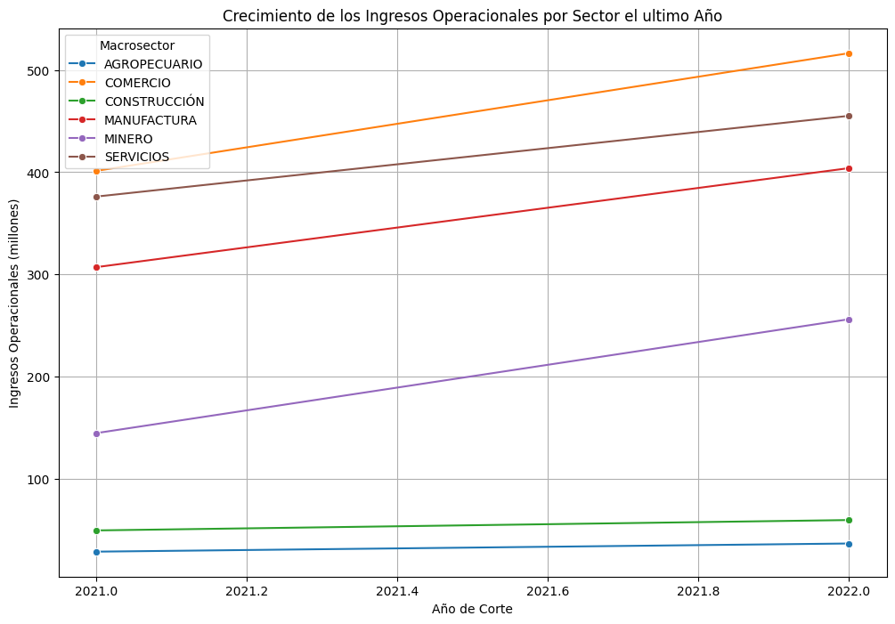

```python
import seaborn as sns

# Crear el gráfico de líneas
plt.figure(figsize=(12, 8))
sns.lineplot(data=df_sector_anual, x='Año de Corte', y='INGRESOS OPERACIONALES', hue='MACROSECTOR', marker='o')

# Configuración del gráfico
plt.title('Crecimiento de los Ingresos Operacionales por Sector el ultimo Año')
plt.xlabel('Año de Corte')
plt.ylabel('Ingresos Operacionales (millones)')
plt.legend(title='Macrosector')
plt.grid(True)

plt.show()
```